# Introduction

This tutorial offers some advice on what to consider when creating surveys and questionnaires, provides tips on visualizing survey data, and exemplifies how survey and questionnaire data can be analyzed. As this tutorial is introductory, issues relating to what software to use when creating a survey (e.g. SurveyMonkey, Qualtrics, GoogleForms, etc.) or how to program questionnaires or online experiments in Java or R are not discussed.

This tutorial is aimed at beginners and intermediate users of R with the aim of showcasing how to visualize and analyze survey and questionnaire data using R. The aim is not to provide a fully-fledged analysis but rather to show and exemplify selected useful methods associated with surveys and questionnaires.

- *Nominal and categorical scales*: Nominal and categorical scales only list the membership of a particular class. Nominal scales offer exactly two options (yes/no or on/off), while categorical scales offer several options (e.g. the state in which someone was born).
- *Ordinal scales*: With *ordinal scales* it is possible to rank the values, but the distances between the ranks can not be exactly quantified. An example of an ordinal scales is the ranking in a 100-meter run. The 2nd in a 100-meter run did not go twice as fast as the 4th. It is often the case that ordinal variables consist of integer, positive numbers (1, 2, 3, 4, etc.). In the context of surveys, ordinal scales are the most important as all Likert scales (after the psychologist Rensis Likert) are ordinal scales. The levels of the typical five-level Likert item could be: *Strongly disagree (1)*, *Disagree (2)* , *Neither agree nor disagree (3)*, *Agree (4)*, and *Strongly agree (5)*. As such, the Likert scale is a bipolar scale that can be balanced, if there is an uneven number of options with the center option being neutral, or unbalanced, if there are an even number of options which forces respondents to express a preferences for wither of the two poles (this is called a “forced choice” method.
- *(True) Numeric scales*: There are two basic types of numeric scales: *interval-scales* and *ratio-scales*. For *interval scales*, the differences between levels are significant, but not the relationship between levels. For instance, 20 degree Celsius is not twice as hot as 10 degree Celsius. For *ratio-scales* both the differences and the relationships between the levels are significant (e.g. the times in a 100-meter dash: 10 is exactly twice as high as 5 and half as much as 20).

Of these scales, numeric is the most informative and questionnaires should always aim to extract the most detailed information without becoming to long.

# Visualizing survey data

Just as the data that is provided by surveys and questionnaires can take various forms, there are numerous ways to display survey data. In the following, we will have a look at some of the most common or useful ways in which survey and questionnaire data can be visualized. However, before we can begin, we need to set up our R session as shown below.

**Preparation and session set up**

To run the scripts shown below without errors, certain *packages* need to be installed from an R *library*. Before turning to the code below, please install the packages by running the code below this paragraph. If you have already installed the packages mentioned below, then you can skip ahead ignore this section. To install the necessary packages, simply run the following code - it may take some time (between 1 and 5 minutes to install all of the libraries so you do not need to worry if it takes some time).

```r
# install packages
install.packages("knitr")
install.packages("lattice")
install.packages("tidyverse")
install.packages("likert")
install.packages("MASS")
install.packages("psych")
install.packages("viridis")
install.packages("ggplot2")
install.packages("here")
install.packages("flextable")
install.packages("devtools")
install.packages("rgr")
install.packages("readxl")
# devtools::install_github("matherion/userfriendlyscience", dependencies=T)
install.packages("ufs")
# install klippy for copy-to-clipboard button in code chunks
install.packages("remotes")
remotes::install_github("rlesur/klippy")
```

You can now activate the packages by running the code chunk below.

```r
# set options
options(stringsAsFactors = F)         # no automatic data transformation
options("scipen" = 100, "digits" = 4) # suppress math annotation
# install packages
library(knitr)
library(lattice)
library(tidyverse)
library(likert)
library(MASS)
library(psych)
library(viridis)
library(ggplot2)
library(here)
library(flextable)
library(devtools)
library(rgr)
library(readxl)
# library(userfriendlyscience)
# activate klippy for copy-to-clipboard button
klippy::klippy()
```

```r
PIGWEB <- read_excel("PIGWEB FAIR survey (2).xlsx")
State_of_Open_Data_2021_Master_data_cleaned <- read_excel("State of Open Data 2021_Master data_cleaned.xlsx", skip = 1)
```

Once you have installed R, RStudio, and have also initiated the session by executing the code shown above, you are good to go.

## Line graphs for Likert-scaled data

```r
# define color vectors
clrs3 <- c("firebrick4",  "gray70", "darkblue")
clrs5 <- c("firebrick4", "firebrick1", "gray70", "blue", "darkblue")
# load data (this is a dataset from a tutorial we used for testing)
#ldat <- base::readRDS(url("https://slcladal.github.io/data/lid.rda", "rb"))
```

Let’s briefly inspect the `pigweb` and state of Open Science data sets. In the displayed pictures we have added column numbers so that we can use the pictures to find which questions are identifical in the different themes.

| 1 Respondent name | 2 Respondent unique ID | 3 Answer created | 4 Answer complete | 5 Information about your research and role in research. : When was the last occasion that you published or submitted a manuscript to a journal? | 6 Information about your research and role in research. : In which year was your first peer-reviewed research article published? | 7 Information about your research and role in research. : Which of the following best describes your primary area of interest? | 8 Information about your research and role in research. : Other (please specify) | 9 Information about your research and role in research. : Who is the main funder of your current research? | 10 Information about your research and role in research. : Does any of your current research involve collaboration with others? : Yes, within my institution | 11 Information about your research and role in research. : Does any of your current research involve collaboration with others? : Yes, within my country | 12 Information about your research and role in research. : Does any of your current research involve collaboration with others? : Yes, internationally | 13 Information about your research and role in research. : Does any of your current research involve collaboration with others? : No | 14 Information about your research and role in research. : Does any of your current research involve collaboration with others? : I don't know | 15 Information about your research and role in research. : To what extent do you agree/disagree with the following statements?:(Use the arrows below to go to next statement, there is a total of three … | 16 Information about your research and role in research. : To what extent do you agree/disagree with the following statements?:(Use the arrows below to go to next statement, there is a total of three … | 17 Information about your research and role in research. : To what extent do you agree/disagree with the following statements?:(Use the arrows below to go to next statement, there is a total of three … | 18 Information about your research and role in research. : How familiar are you with the FAIR data principles in relation to open data? | 19 Information about your research and role in research. : Does your country have an open data policy relating to FAIR? | 20 Information about your research and role in research. : Does your university/institute have an open data policy relating to FAIR? | 21 Information about your research and role in research. : Do any of your main funders have an open data policy relating to FAIR? | 22 About your research data : Do you curate/prepare your data for sharing during or shortly after the data collection process either privately or publicly? | 23 About your research data : No, other (please specify) | 24 About your research data : Have you created a data management plan for your current research?(Please select all that apply : Yes, it was a requirement of my current funder | 25 About your research data : Have you created a data management plan for your current research?(Please select all that apply : Yes, it was a requirement of my institution | 26 About your research data : Have you created a data management plan for your current research?(Please select all that apply : Yes, it is a requirement of the journal I plan to submit to | 27 About your research data : Have you created a data management plan for your current research?(Please select all that apply : Yes, but not as a result of any requirement | 28 About your research data : Have you created a data management plan for your current research?(Please select all that apply : No | 29 About your research data : Have you created a data management plan for your current research?(Please select all that apply : I don't know | 30 About your research data : To what extent do you think you make your data open in compliance with FAIR? | … |
| --- | --- | --- | --- | --- | --- | --- | --- | --- | --- | --- | --- | --- | --- | --- | --- | --- | --- | --- | --- | --- | --- | --- | --- | --- | --- | --- | --- | --- | --- | --- |
| Generell länk | 255,977,069 | 2021-09-13 09:48:58 |  | 2 | 2010 | 2 |  | University funding |  |  | 1 |  |  | 1 | 1 | 1 | 2 | 3 | 3 | 1 | 1 |  |  |  |  |  |  |  | 1 | … |
| Generell länk | 255,998,073 | 2021-09-13 12:10:43 | 2021-09-13 12:29:36 | 1 | 2010 | 12 | Agriculture | State. | 1 | 1 | 1 |  |  | 1 | 1 | 1 | 2 | 3 | 3 | 1 | 2 |  | 1 | 1 |  |  |  |  | 2 | … |
| Generell länk | 255,999,250 | 2021-09-13 12:22:25 |  | 1 |  | 2 |  | The Swiss government | 1 | 1 | 1 |  |  | 1 | 1 | 1 | 1 | 3 | 2 | 3 | 6 |  | 1 |  |  |  |  |  | 5 | … |
| Generell länk | 256,001,965 | 2021-09-13 12:41:03 |  | 1 | 2007 | 2 |  | public local government | 1 | 1 | 1 |  |  | 3 | 4 | 5 | 2 | 1 | 1 | 3 |  |  |  |  |  |  |  |  |  | … |
| Generell länk | 256,002,708 | 2021-09-13 12:48:41 | 2021-09-13 13:09:40 | 1 | 2007 | 2 |  | I work at a publicly funded research institute, with additional funding mostly from the DFG and EU. | 1 | 1 | 1 |  |  | 2 | 2 | 2 | 2 | 3 | 3 | 3 | 6 |  |  | 1 |  |  |  |  | 2 | … |
| Generell länk | 256,019,631 | 2021-09-13 14:58:42 | 2021-09-13 15:11:12 | 1 | 2007 | 2 |  | The German Government | 1 | 1 | 1 |  |  | 1 | 1 | 1 | 2 | 3 | 3 | 3 | 2 |  |  | 1 |  |  |  |  | 2 | … |
| Generell länk | 256,026,620 | 2021-09-13 15:47:25 | 2021-09-13 16:18:29 | 1 | 2013 | 2 |  | There is no main funder as my current research is divided over several different projects with different funders. | 1 |  | 1 |  |  | 3 | 4 | 4 | 2 | 3 | 3 | 3 | 1 |  |  | 1 |  |  |  |  | 4 | … |
| Generell länk | 256,032,817 | 2021-09-13 16:20:41 | 2021-09-13 16:30:48 | 1 | 2003 | 12 | Animal Sciences |  | 1 | 1 | 1 |  |  | 2 | 3 | 3 | 2 | 3 | 3 | 3 | 2 |  |  |  |  |  | 1 |  | 4 | … |
| Generell länk | 256,064,531 | 2021-09-13 21:23:06 | 2021-09-13 21:40:37 | 1 |  | 2 |  | Europe Funds | 1 | 1 | 1 |  |  | 1 | 1 | 1 | 1 | 1 | 1 | 3 | 2 |  |  |  |  |  | 1 |  | 2 | … |
| Generell länk | 256,081,511 | 2021-09-14 08:22:47 | 2021-09-14 08:47:09 | 1 | 2008 | 2 |  | private foundations | 1 | 1 | 1 |  |  | 1 | 1 | 2 | 2 | 1 | 2 | 2 | 2 |  |  |  |  |  | 1 |  | 3 | … |

First 10 rows of the SoD21 data set.

| 1 Year | 2 Start Date | 3 End Date | 4 Progress | 5 Duration (in seconds) | 6 Finished | 7 Recorded Date | 8 Response ID | 9 User Language | 10 To provide a little more context for your later responses we would first like to understand a little about your research and attitudes towards open science. When was the last occasion that you publ… | 11 In which year was your first peer-reviewed research article published? | 12 Which of the following best describes your primary area of interest? - Selected Choice | 13 Which of the following best describes your primary area of interest? - Other (please specify) - Text | 14 Does any of your current research involve collaboration with others? (Please select all that apply) - Yes, within my institution | 15 Does any of your current research involve collaboration with others? (Please select all that apply) - Yes, within my country | 16 Does any of your current research involve collaboration with others? (Please select all that apply) - Yes, internationally | 17 Does any of your current research involve collaboration with others? (Please select all that apply) - No | 18 Does any of your current research involve collaboration with others? (Please select all that apply) - I don't know | 19 To what extent do you agree/disagree with the following statements?: - Making research articles open access should be common scholarly practice | 20 To what extent do you agree/disagree with the following statements?: - Making research data openly available should be common scholarly practice | 21 To what extent do you agree/disagree with the following statements?: - Making all research outputs openly available should be common scholarly practices | 22 How familiar are you with the FAIR data principles in relation to open data? [Note: FAIR data principles correspond to data that is Findable, Accessible, Interoperable, and Reusable] | 23 About your research data Do you curate/prepare your data for sharing during or shortly after the data collection process either privately or publicly? - Selected Choice | 24 About your research data Do you curate/prepare your data for sharing during or shortly after the data collection process either privately or publicly? - No, other (please specify) - Text | 25 Have you created a data management plan for your current research? (Please select all that apply) - Yes, it was a requirement of my current funder | 26 Have you created a data management plan for your current research? (Please select all that apply) - Yes, it was a requirement of my institution | 27 Have you created a data management plan for your current research? (Please select all that apply) - Yes, it is a requirement of the journal I plan to submit to | 28 Have you created a data management plan for your current research? (Please select all that apply) - Yes, but not as a result of any requirement | 29 Have you created a data management plan for your current research? (Please select all that apply) - No | 30 Have you created a data management plan for your current research? (Please select all that apply) - I don't know | … |
| --- | --- | --- | --- | --- | --- | --- | --- | --- | --- | --- | --- | --- | --- | --- | --- | --- | --- | --- | --- | --- | --- | --- | --- | --- | --- | --- | --- | --- | --- | --- |
| 2,021 | 2021-05-27 03:06:41 | 2021-05-27 03:26:37 | 100 | 1,195 | TRUE | 2021-05-27 03:26:39 | R_2cq2qgw3nBBoCRK | EN | Within the last year | 2,021 | Physics | 0 | Yes, within my institution | 0 | 0 | 0 | 0 | Strongly agree | Strongly agree | Strongly agree | I have previously heard of the FAIR data principles but I am not familiar with them | No, its not important with our data | 0 | 0 | 0 | 0 | Yes, but not as a result of any requirement | 0 | 0 | … |
| 2,021 | 2021-05-28 11:26:44 | 2021-05-28 11:36:38 | 100 | 594 | TRUE | 2021-05-28 11:36:39 | R_1GDm3GHQSaccD03 | JA | Within the last year | 1,987 | Physics | 0 | Yes, within my institution | 0 | 0 | 0 | 0 | Somewhat agree | Somewhat agree | Somewhat agree | I have never heard of the FAIR data principles before now | No, its not important with our data | 0 | 0 | 0 | 0 | 0 | No | 0 | … |
| 2,021 | 2021-05-25 15:07:40 | 2021-05-25 15:16:38 | 90 | 537 | FALSE | 2021-06-01 15:16:39 | R_2A1haat1HvCw8vE | EN | Within the last year | 2,012 | Medicine | 0 | Yes, within my institution | 0 | 0 | 0 | 0 | Strongly agree | Strongly agree | Strongly agree | I have never heard of the FAIR data principles before now | No, its not important with our data | 0 | 0 | 0 | 0 | 0 | No | 0 | … |
| 2,021 | 2021-06-03 19:34:50 | 2021-06-03 19:47:12 | 100 | 742 | TRUE | 2021-06-03 19:47:13 | R_28Znode8fdsj7GP | EN | Within the last year | 2,004 | Earth and Environmental Science | 0 | Yes, within my institution | Yes, within my country | Yes, internationally | 0 | 0 | Somewhat agree | Neutral | Neutral | I have previously heard of the FAIR data principles but I am not familiar with them | No, other (please specify) | Data made publicly available after study and not during collection | 0 | 0 | 0 | 0 | No | 0 | … |
| 2,021 | 2021-05-26 16:06:22 | 2021-05-26 16:17:27 | 100 | 665 | TRUE | 2021-05-26 16:17:28 | R_3OqvtAAZOqOnimg | EN | 1-2 years ago | 2,002 | Physics | 0 | Yes, within my institution | 0 | Yes, internationally | 0 | 0 | Strongly disagree | Strongly agree | Strongly agree | I have previously heard of the FAIR data principles but I am not familiar with them | No, we don't have the resource to do this but we would like to | 0 | 0 | 0 | 0 | 0 | No | 0 | … |
| 2,021 | 2021-05-26 21:31:31 | 2021-05-26 21:46:33 | 100 | 901 | TRUE | 2021-05-26 21:46:35 | R_1gwKUhYU0ud55zs | JA | 3-5 years ago | 1,997 | Biology | 0 | 0 | 0 | Yes, internationally | 0 | 0 | Strongly agree | Neutral | Neutral | I have never heard of the FAIR data principles before now | No, we don't have the resource to do this but we would like to | 0 | 0 | 0 | 0 | 0 | No | 0 | … |
| 2,021 | 2021-05-27 00:09:40 | 2021-05-27 00:15:32 | 100 | 352 | TRUE | 2021-05-27 00:15:33 | R_3ke4jhBKO7EYREN | JA | Within the last year | 2,006 | Biology | 0 | 0 | 0 | 0 | No | 0 | Somewhat agree | Somewhat agree | Somewhat agree | I have never heard of the FAIR data principles before now | No, we don't have the resource to do this but we would like to | 0 | 0 | 0 | 0 | Yes, but not as a result of any requirement | 0 | 0 | … |
| 2,021 | 2021-05-27 00:17:04 | 2021-05-27 00:30:38 | 100 | 813 | TRUE | 2021-05-27 00:30:38 | R_3svpcHev6BCmwmp | EN | Within the last year | 1,991 | Physics | 0 | 0 | 0 | Yes, internationally | 0 | 0 | Strongly agree | Strongly agree | Strongly agree | I have previously heard of the FAIR data principles but I am not familiar with them | No, we don't have the resource to do this but we would like to | 0 | 0 | 0 | 0 | Yes, but not as a result of any requirement | 0 | 0 | … |
| 2,021 | 2021-05-25 15:18:45 | 2021-05-25 15:50:30 | 90 | 1,904 | FALSE | 2021-06-01 15:50:30 | R_oXeJd7mPlXNCHex | EN | Within the last year | 1,981 | Other (please specify) | mathematical modeling | Yes, within my institution | 0 | 0 | 0 | 0 | Strongly agree | Somewhat agree | Somewhat agree | I have never heard of the FAIR data principles before now | No, its not important with our data | 0 | 0 | 0 | 0 | 0 | No | 0 | … |
| 2,021 | 2021-05-28 09:48:19 | 2021-05-28 09:57:22 | 100 | 543 | TRUE | 2021-05-28 09:57:23 | R_216TLbutyQEF6WF | EN | Within the last year | 2,020 | Physics | 0 | 0 | 0 | Yes, internationally | 0 | 0 | Strongly agree | Somewhat agree | Somewhat agree | I have never heard of the FAIR data principles before now | No, we don't have the resource to do this but we would like to | 0 | Yes, it was a requirement of my current funder | 0 | 0 | 0 | 0 | 0 | … |

This is a pretty big dataset with multiple data structures so we need to proceed carefully in terms of how we analyse data. We will use a number of different blocks to analyse different kinds of questions. Note: There is a comma in the flextable for state of Open Data table (column 11) which is caused by Anglo-saxon numbers often not following ISO-standards on how to write numbers using digit group separators (ie 2,021 should be read as 2021).

The respondent data provided in the questionnaires cover three single answer questions and one multiple choice question regarding collaboration. The single answer questions were ‘When was the last occasion that you published or submitted a manuscript to a journal?’, ‘In which year was your first peer-reviewed research article published?’and ’Which of the following best describes your primary area of interest?’ while the multiple answers question was ’ Does any of your current research involve collaboration with others?’.

#Information about the research of the respondents

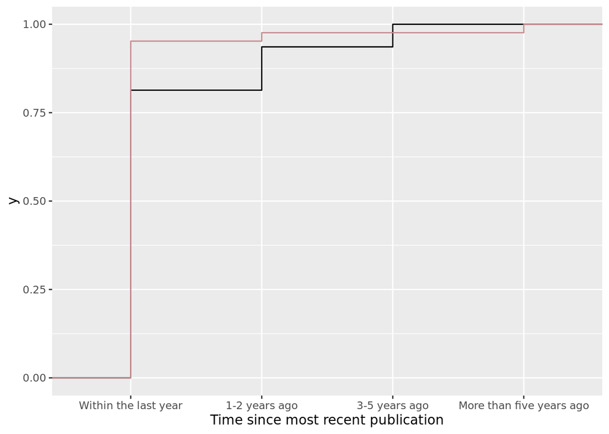

```r
#First section in this chunk select the columns from the two surveys, set the column names to Q1-Q8 and a vector of the questions is saved.
#For each question the answers are then harmonised and displayed together in a diagram or table.


#Selecting columns from each dataset, harmonising column names using dplyr select and then harmonising response variables.
respondentsSoD21 = dplyr::select(sod21,10:18)
respondentsSoD21$source = 'sod'
respondentsPig = dplyr::select(pigweb,5:7,10:14)
respondentsPig$source = 'pig'
outPutNames= c('When was the last occasion that you published or submitted a manuscript to a journal?', 'In which year was your first peer-reviewed research article published?', 'Which of the following best describes your primary area of interest?','Yes, within my institution','Yes, within my country','Yes internationally','No', 'I dont know')
colnames(respondentsSoD21) = c('Q1', 'Q2', 'Q3','Q4','Q5','Q6','Q7', 'Q8')
colnames(respondentsPig) = c('Q1', 'Q2', 'Q3','Q4','Q5','Q6','Q7', 'Q8')

#unique(respondentsSoD21) #unique() is used to identify the unique answers of the question.
respondentsSoD21$Q1 = dplyr::recode(respondentsSoD21$Q1, "Within the last year" = 1, "1-2 years ago" = 2, "3-5 years ago" = 3, "More than 5 years ago" = 4, "I have never submitted a manuscript to a journal" = 5)
ggplot() +
     geom_step(aes(x = as.numeric(Q1)), data = respondentsSoD21, stat = "ecdf") +
     geom_step(aes(x = as.numeric(Q1)), data = respondentsPig, stat = "ecdf", color="#c78b90") +
  scale_x_discrete("Time since most recent publication", limits = c("Within the last year", "1-2 years ago", "3-5 years ago", "More than five years ago"))
```

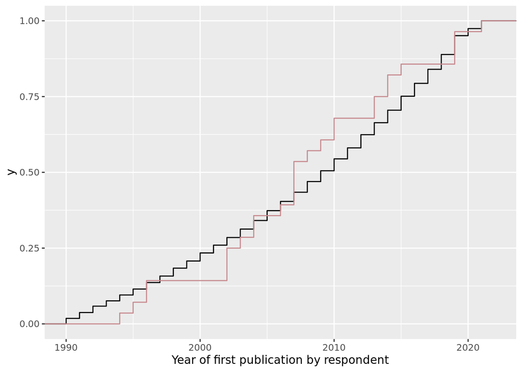

```r
#Necessary harmonisation of response formats
respondentsPig$Q2=as.numeric(respondentsPig$Q2)

respondentsSod21Pub = subset(respondentsSoD21, !Q2==0)
ggplot() +
     geom_step(aes(x = as.numeric(Q2)), data = respondentsSod21Pub, stat = "ecdf") +
     geom_step(aes(x = as.numeric(Q2)), data = respondentsPig, stat = "ecdf", color="#c78b90") +
  scale_x_continuous(limits = c(1990, 2022)) +
  xlab("Year of first publication by respondent")
```

```r
ks.test(respondentsSod21Pub$Q1, respondentsPig$Q1, ifresult = FALSE) #Kolmogorov-Smirnov test for Q1
```

```
##
##  Two-sample Kolmogorov-Smirnov test
##
## data:  respondentsSod21Pub$Q1 and respondentsPig$Q1
## D = 0.14, p-value = 0.4
## alternative hypothesis: two-sided
```

```r
ks.test(respondentsSod21Pub$Q2, respondentsPig$Q2, ifresult = FALSE) #Kolmogorov-Smirnov test for Q2
```

```
##
##  Two-sample Kolmogorov-Smirnov test
##
## data:  respondentsSod21Pub$Q2 and respondentsPig$Q2
## D = 0.15, p-value = 0.5
## alternative hypothesis: two-sided
```

```r
#ggplot(respondentsSoD21, aes(respondentsSoD21$Q2), xlim(1990,2022)) +
#  stat_ecdf(geom = "step") +
#  scale_x_continuous(limits = c(1990, 2022))

#ggplot(respondentsPig, aes(x = as.numeric(respondentsPig$Q2)), #xlim(1990,2022)) +
#  stat_ecdf(geom = "step") +
#  scale_x_continuous(limits = c(1990, 2022))

#ggplot(respondentsPig, aes(x=Q1))+stat_ecdf(geom = #"step")+theme_classic()
```

# Citation & Session Info

This is a heavily modified version of the tutorial Schweinberger, Martin. 2020. *Questionnaires and Surveys: Analyses with R*. Brisbane: The University of Queensland. url: https://slcladal.github.io/surveys.html (Version 2020.12.11).

```
@manual{PigWebSurvey,
  author = {Klingström, Tomas},
  title = {PigWeb Survey},
  note = {Not yet public},
  year = {2022},
  organization = "Swedish University of Agricultural Sciences},
  address = {Uppsala},
  edition = {2022/04/27}
}
```

# References

Back to top

[Back to HOME](https://slcladal.github.io/index.html)